# Chicago_Food_Inspections

```python
# @hidden_cell
#Import required packages
import pandas as pd
import numpy as np
import matplotlib.pyplot as plt
%matplotlib inline
import pymysql.cursors
import ast
import os,conda
conda_file_dir = conda.__file__
conda_dir = conda_file_dir.split('lib')[0]
proj_lib = os.path.join(os.path.join(conda_dir, 'Library'), 'share')
os.environ["PROJ_LIB"] = proj_lib
from mpl_toolkits.basemap import Basemap
from datetime import datetime
pd.options.mode.chained_assignment = None
```

#### Import chicago food inspection data taken from the below link.

https://data.cityofchicago.org/Health-Human-Services/Food-Inspections/4ijn-s7e5/data

Description:

This information is derived from inspections of restaurants and other food establishments in Chicago from January 1, 2010 to the present.

variables include:

DBA: "Doing Business as"

AKA: "Also known as"

License #: "License number"

Facility Type: Type of the facility like Restaurant, hospital, groceries, gas station etc..

Risk: Each establishment is categorized as Risk 1, 2, 3

Street address, city, state, zip code

Inspection type: Canvass, complaint, suspected food-poisoning

Results: pass, pass with conditions, fail, out of business, etc..

Violations: violation number, description of findings

```python
connection = pymysql.connect(host='localhost', user='root', password='root', db='food')
```

```python
#Test pandas read_sql
df = pd.read_sql('SELECT * from food_inspections', con = connection)
df.head(2)
```

|  | Inspection_ID | DBA_Name | AKA_Name | License | Facility_Type | Risk | Address | City | State | Zip | Inspection_Date | Inspection_Type | Results | Latitude | Longitude | Location |
| --- | --- | --- | --- | --- | --- | --- | --- | --- | --- | --- | --- | --- | --- | --- | --- | --- |
| 0 | 44247 | EAT A PITA | EAT A PITA | 1222441 | Restaurant | Risk 1 (High) | 3155 N HALSTED ST | CHICAGO | IL | 60657 | 2010-01-05 | Complaint | Pass | 41.9394 | -87.6491 | (41.93944115701468, -87.64910277148812) |
| 1 | 44248 | LA GONDOLA | LA GONDOLA | 1336561 | Restaurant | Risk 1 (High) | 2914 N ASHLAND AVE | CHICAGO | IL | 60657 | 2010-01-21 | Canvass | Pass | 41.9347 | -87.6686 | (41.93467889167928, -87.66862496860755) |

```python
inspections_data = pd.read_csv("Food_Inspections.csv")
```

```python
print(inspections_data.shape)
inspections_data.head(2)
```

```
(178432, 17)
```

|  | Inspection ID | DBA Name | AKA Name | License # | Facility Type | Risk | Address | City | State | Zip | Inspection Date | Inspection Type | Results | Violations | Latitude | Longitude | Location |
| --- | --- | --- | --- | --- | --- | --- | --- | --- | --- | --- | --- | --- | --- | --- | --- | --- | --- |
| 0 | 2240740 | AFRICAN JERK | AFRICAN JERK | 2564245.0 | Restaurant | Risk 1 (High) | 1708 W 63RD ST | CHICAGO | IL | 60636.0 | 11/28/2018 | Canvass | Out of Business | NaN | 41.779521 | -87.667094 | (41.77952128488156, -87.6670936713993) |
| 1 | 2240743 | ALL ABOUT KIDS LEARNING ACADEMY | ALL ABOUT KIDS LEARNING ACADEMY | 2384881.0 | Children's Services Facility | Risk 1 (High) | 504-516 E 75TH ST | CHICAGO | IL | 60619.0 | 11/28/2018 | License | Pass w/ Conditions | 3. MANAGEMENT, FOOD EMPLOYEE AND CONDITIONAL E... | 41.758567 | -87.612451 | (41.758566800153645, -87.61245073862713) |

#### Make changes for the csv file so that the csv can be imported into sql table.

```python
sql_csv = inspections_data
sql_csv.drop(columns = ["Violations"], inplace = True)
sql_csv.to_csv("Food_Inspections_sql.csv", index = False)
```

#### Check for missing values in the data

```python
inspections_data.isnull().sum()
```

```
Inspection ID         0
DBA Name              0
AKA Name           2438
License #            16
Facility Type      4711
Risk                 68
Address               0
City                155
State                33
Zip                  75
Inspection Date       0
Inspection Type       1
Results               0
Latitude            668
Longitude           668
Location            668
dtype: int64
```

#### Here we have around 668 rows with no location. Let`s delete them.

```python
inspections_data.dropna(subset = ['Location'], inplace = True)
print(len(inspections_data))
```

```
177764
```

```python
inspections_data.isnull().sum()
```

```
Inspection ID         0
DBA Name              0
AKA Name           2421
License #            16
Facility Type      4697
Risk                 66
Address               0
City                148
State                33
Zip                  66
Inspection Date       0
Inspection Type       1
Results               0
Latitude              0
Longitude             0
Location              0
dtype: int64
```

#### Results column shows the result of the inspection. Inspections with values pass, pass with conditions or fail are of interest to us. We will delete the Inspections with other values in the results column.

```python
print("All possible unique values of Results column:\n", inspections_data.Results.unique())
inspections_data = inspections_data[inspections_data.Results.isin(['Pass', 'Pass w/ Conditions', 'Fail'])]
#Around 22500 inspections were discarded.
print(len(inspections_data))
```

```
All possible unique values of Results column:
 ['Out of Business' 'Pass w/ Conditions' 'Pass' 'Not Ready' 'Fail'
 'No Entry' 'Business Not Located']
155305
```

#### If there are any duplicate rows, drop them.

```python
inspections_data.drop_duplicates(inplace=True)
print(len(inspections_data))
```

```
155305
```

#### For our graphs/inferences to be more accurate, it is better to maintain consistency. So we change all values of some columns to uppercase. But this doesn`t solve other problems in naming conventions(like space, special characters etc..)

```python
inspections_data['DBA Name'] = inspections_data['DBA Name'].str.upper()
inspections_data['DBA Name'] = inspections_data['DBA Name'].str.replace("'", "")
inspections_data['Facility Type'] = inspections_data['Facility Type'].str.upper()
```

### 2) Let`s plot some bar graphs for variables in the data.

#### (i) Plot the number of inspections (frequency) for each result type

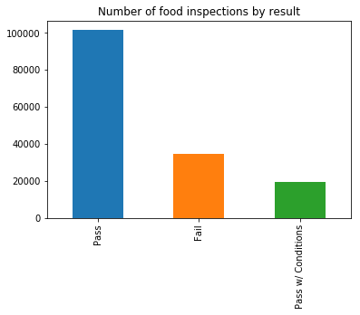

```python
inspections_data.Results.value_counts().plot(kind = 'bar', title = 'Number of food inspections by result')
#So we have a lot of inspections which passed(around 1 lakh)
```

Hence, We have a lot of inspections with result pass.

#### (ii) Plot the number of inspections per month

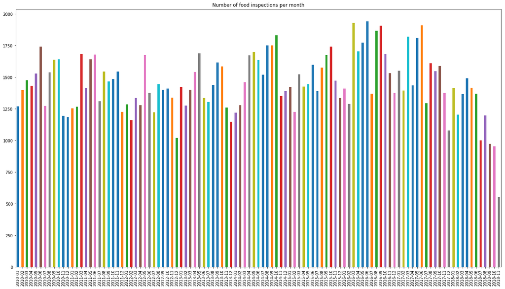

```python
inspections_data['Inspection Date'] = pd.to_datetime(inspections_data['Inspection Date'])
inspections_per_month = inspections_data['Inspection Date'].dt.to_period('M').value_counts()
inspections_per_month.sort_index(inplace = True)
inspections_per_month.plot(kind = 'bar', figsize = (22, 12), title = "Number of food inspections per month")
```

The above plot shows the number of inspections per month from 2010 to 2018.

#### (iii) Plot the number of inspections for each risk type

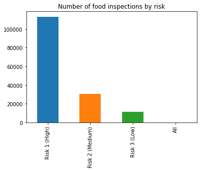

```python
inspections_data.Risk.value_counts().plot(kind = 'bar', title = 'Number of food inspections by risk')
```

Each establishment is categorized as to its risk of adversely affecting the public’s health, with 1 being the highest and 3 the lowest. The frequency of inspection is tied to this risk.

#### (iv) Plot the number of inspections by zipcode

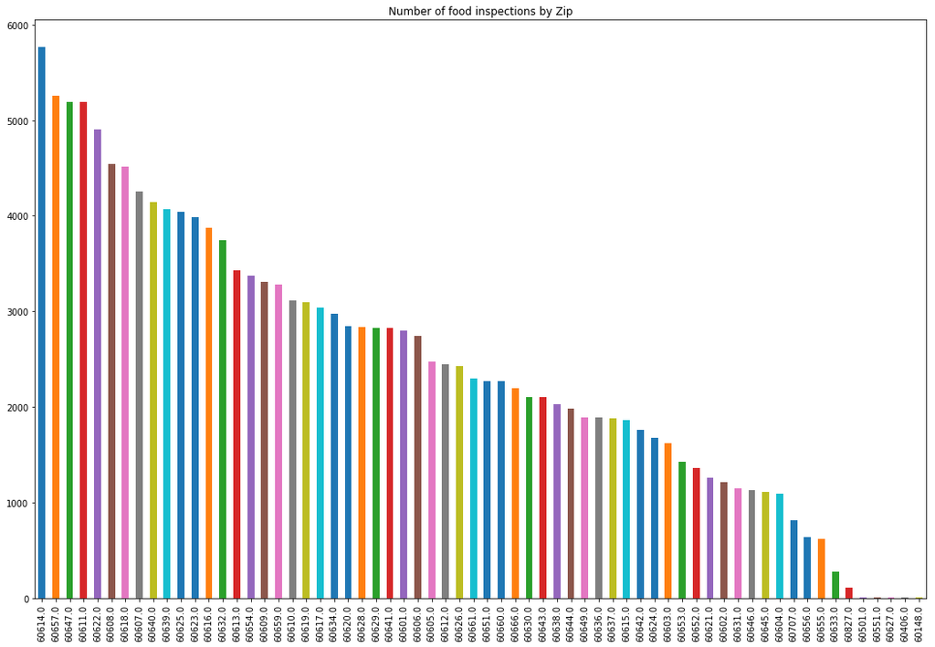

```python
inspections_data.Zip.value_counts().plot(kind = 'bar', title = 'Number of food inspections by Zip', figsize = (18, 12))
```

#### (v) Plot the number of inspections for first 20 facility types with most inspections.

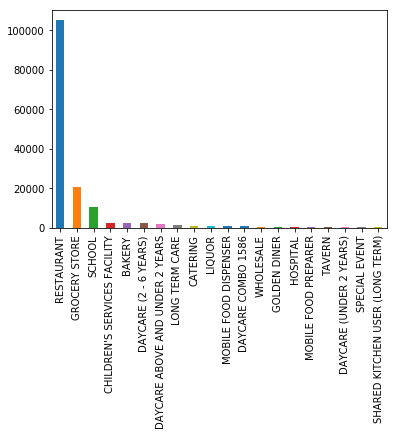

```python
inspections_data['Facility Type'].value_counts()[0:20].plot(kind = 'bar')
```

#### (vi) Plot the number of inspections for first 30 addresses with most inspections.

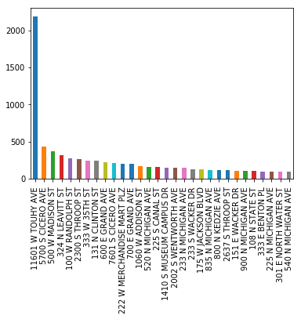

```python
inspections_data.Address.value_counts()[0:30].plot(kind = 'bar')
```

#### (vii) Plot the number of inspections for first 10 inspection types with most inspections.

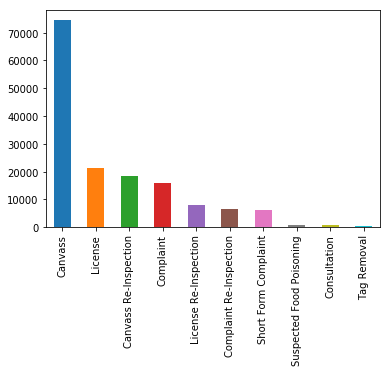

```python
inspections_data['Inspection Type'].value_counts()[0:10].plot(kind = 'bar')
```

#### (viii) Top 20 food chains with most inspections.

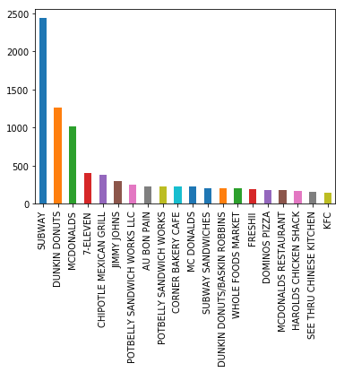

```python
inspections_data['DBA Name'].value_counts()[0:20].plot(kind = 'bar')
```

```python
inspections_data[inspections_data.Address == '11601 W TOUHY AVE ']
```

|  | Inspection ID | DBA Name | AKA Name | License # | Facility Type | Risk | Address | City | State | Zip | Inspection Date | Inspection Type | Results | Latitude | Longitude | Location |
| --- | --- | --- | --- | --- | --- | --- | --- | --- | --- | --- | --- | --- | --- | --- | --- | --- |
| 177 | 2240323 | HUB 51 | HUB 51/T5 M10 | 2192977.0 | RESTAURANT | Risk 1 (High) | 11601 W TOUHY AVE | CHICAGO | IL | 60666.0 | 2018-11-16 | Canvass Re-Inspection | Pass w/ Conditions | 42.008536 | -87.914428 | (42.008536400868735, -87.91442843927047) |
| 195 | 2240295 | WOW BAO | WOW BAO/T5 M-10 | 2308553.0 | RESTAURANT | Risk 1 (High) | 11601 W TOUHY AVE | CHICAGO | IL | 60666.0 | 2018-11-16 | Canvass | Fail | 42.008536 | -87.914428 | (42.008536400868735, -87.91442843927047) |
| 199 | 2240294 | RJ GRUNTS | RJ GRUNTS/T5 M10 | 2308567.0 | RESTAURANT | Risk 1 (High) | 11601 W TOUHY AVE | CHICAGO | IL | 60666.0 | 2018-11-16 | Canvass | Pass w/ Conditions | 42.008536 | -87.914428 | (42.008536400868735, -87.91442843927047) |
| 210 | 2240270 | THE GODDESS & GROCER | THE GODDESS & GROCER/T-5 OUTSIDE SECURITY | 2299087.0 | RESTAURANT | Risk 1 (High) | 11601 W TOUHY AVE | CHICAGO | IL | 60666.0 | 2018-11-16 | Canvass Re-Inspection | Pass | 42.008536 | -87.914428 | (42.008536400868735, -87.91442843927047) |
| 275 | 2233172 | THE GODDESS & GROCER | THE GODDESS & GROCER/T-5 OUTSIDE SECURITY | 2299087.0 | RESTAURANT | Risk 1 (High) | 11601 W TOUHY AVE | CHICAGO | IL | 60666.0 | 2018-11-14 | Canvass | Pass w/ Conditions | 42.008536 | -87.914428 | (42.008536400868735, -87.91442843927047) |
| 282 | 2233163 | UNITED CLUB | UNITED CLUB (T1-B6) | 2464515.0 | RESTAURANT | Risk 1 (High) | 11601 W TOUHY AVE | CHICAGO | IL | 60666.0 | 2018-11-14 | Canvass Re-Inspection | Pass | 42.008536 | -87.914428 | (42.008536400868735, -87.91442843927047) |
| 287 | 2233155 | MCDONALDS # 22821 | McDONALD'S (T2 E/F) | 2487933.0 | RESTAURANT | Risk 2 (Medium) | 11601 W TOUHY AVE | CHICAGO | IL | 60666.0 | 2018-11-14 | Canvass Re-Inspection | Pass | 42.008536 | -87.914428 | (42.008536400868735, -87.91442843927047) |
| 312 | 2233111 | HUB 51 | HUB 51/T5 M10 | 2192977.0 | RESTAURANT | Risk 1 (High) | 11601 W TOUHY AVE | CHICAGO | IL | 60666.0 | 2018-11-13 | Canvass | Fail | 42.008536 | -87.914428 | (42.008536400868735, -87.91442843927047) |
| 322 | 2233095 | BIG BOWL | BIG BOWL (T5/M7) | 2192971.0 | RESTAURANT | Risk 1 (High) | 11601 W TOUHY AVE | CHICAGO | IL | 60666.0 | 2018-11-13 | Canvass | Fail | 42.008536 | -87.914428 | (42.008536400868735, -87.91442843927047) |
| 382 | 2233025 | SWISS AIR | SWISS AIR LOUNGE (DEPARTURE (M9) | 2487938.0 | RESTAURANT | Risk 1 (High) | 11601 W TOUHY AVE | CHICAGO | IL | 60666.0 | 2018-11-09 | Canvass | Pass w/ Conditions | 42.008536 | -87.914428 | (42.008536400868735, -87.91442843927047) |
| 400 | 2232999 | BRITISH AIRWAYS | BRITISH AIRWAYS-TERRACE (T5-M11) | 2522168.0 | RESTAURANT | Risk 1 (High) | 11601 W TOUHY AVE | NaN | IL | 60666.0 | 2018-11-09 | Canvass | Pass | 42.008536 | -87.914428 | (42.008536400868735, -87.91442843927047) |
| 470 | 2232910 | SAS | Scandinavian Lounge (T5-M13) | 2487849.0 | AIRPORT LOUNGE | Risk 2 (Medium) | 11601 W TOUHY AVE | CHICAGO | IL | 60666.0 | 2018-11-07 | Canvass | Pass w/ Conditions | 42.008536 | -87.914428 | (42.008536400868735, -87.91442843927047) |
| 492 | 2232881 | HILTON OHARE | HILTON O'HARE & ANDIAMO | 2535609.0 | RESTAURANT | Risk 1 (High) | 11601 W TOUHY AVE | CHICAGO | IL | 60666.0 | 2018-11-07 | Canvass | Fail | 42.008536 | -87.914428 | (42.008536400868735, -87.91442843927047) |
| 504 | 2232773 | UNITED CLUB | UNITED CLUB (T1-C16) | 2464521.0 | RESTAURANT | Risk 1 (High) | 11601 W TOUHY AVE | CHICAGO | IL | 60666.0 | 2018-11-05 | Canvass | Pass | 42.008536 | -87.914428 | (42.008536400868735, -87.91442843927047) |
| 510 | 2232858 | POLARIS CLUB | POLARIS CLUB (T1-C) | 2564648.0 | RESTAURANT | Risk 1 (High) | 11601 W TOUHY AVE | CHICAGO | IL | 60666.0 | 2018-11-06 | Canvass | Pass w/ Conditions | 42.008536 | -87.914428 | (42.008536400868735, -87.91442843927047) |
| 530 | 2232831 | TRAVEL TRADERS #3081 @ HILTON OHARE | TRAVEL TRADERS/HILTON LOBBY | 2141979.0 | GROCERY STORE | Risk 3 (Low) | 11601 W TOUHY AVE | CHICAGO | IL | 60666.0 | 2018-11-06 | Canvass | Pass w/ Conditions | 42.008536 | -87.914428 | (42.008536400868735, -87.91442843927047) |
| 599 | 2232730 | SODEXO AMERICA, LLC | UNITED EMPLOYEE CAFETERIA (T1-C MID LEVEL) | 2560546.0 | RESTAURANT | Risk 1 (High) | 11601 W TOUHY AVE | CHICAGO | IL | 60666.0 | 2018-11-05 | Canvass | Pass w/ Conditions | 42.008536 | -87.914428 | (42.008536400868735, -87.91442843927047) |
| 754 | 2232536 | MCDONALDS # 22821 | McDONALD'S (T2 E/F) | 2487933.0 | RESTAURANT | Risk 2 (Medium) | 11601 W TOUHY AVE | CHICAGO | IL | 60666.0 | 2018-10-30 | Canvass | Pass w/ Conditions | 42.008536 | -87.914428 | (42.008536400868735, -87.91442843927047) |
| 760 | 2232524 | AUNTIE ANNES PRETZELS | Auntie Anne's Pretzels (T2 E/F) | 1942304.0 | RESTAURANT | Risk 2 (Medium) | 11601 W TOUHY AVE | CHICAGO | IL | 60666.0 | 2018-10-30 | Canvass Re-Inspection | Pass w/ Conditions | 42.008536 | -87.914428 | (42.008536400868735, -87.91442843927047) |
| 763 | 2232518 | DELTA SKY CLUB | DELTA SKY CLUB (T2-E05) | 1356711.0 | RESTAURANT | Risk 1 (High) | 11601 W TOUHY AVE | CHICAGO | IL | 60666.0 | 2018-10-30 | Canvass Re-Inspection | Pass | 42.008536 | -87.914428 | (42.008536400868735, -87.91442843927047) |
| 780 | 2232492 | MCDONALDS RESTAURANT | MCDONALD'S RESTAURANT (T3 H9) | 51206.0 | RESTAURANT | Risk 1 (High) | 11601 W TOUHY AVE | CHICAGO | IL | 60666.0 | 2018-10-30 | Canvass | Pass | 42.008536 | -87.914428 | (42.008536400868735, -87.91442843927047) |
| 800 | 2232461 | HUDSON NEWS | HUDSON NEWS/T-1 C26 | 2313788.0 | STORE | Risk 3 (Low) | 11601 W TOUHY AVE | CHICAGO | IL | 60666.0 | 2018-10-29 | Canvass | Pass w/ Conditions | 42.008536 | -87.914428 | (42.008536400868735, -87.91442843927047) |
| 823 | 2232434 | UNITED CLUB | UNITED CLUB (T1-B6) | 2464515.0 | RESTAURANT | Risk 1 (High) | 11601 W TOUHY AVE | CHICAGO | IL | 60666.0 | 2018-10-29 | Canvass | Pass w/ Conditions | 42.008536 | -87.914428 | (42.008536400868735, -87.91442843927047) |
| 874 | 2232373 | GARRETT POPCORN SHOPS | GARRETT POPCORN SHOPS (T3 H2) | 1898075.0 | GROCERY STORE | Risk 2 (Medium) | 11601 W TOUHY AVE | CHICAGO | IL | 60666.0 | 2018-10-26 | Canvass | Pass w/ Conditions | 42.008536 | -87.914428 | (42.008536400868735, -87.91442843927047) |
| 890 | 2229454 | BEAUDEVIN WINE BAR | BEAUDEVIN WINE BAR/T1 C-16 | 2363769.0 | RESTAURANT | Risk 3 (Low) | 11601 W TOUHY AVE | CHICAGO | IL | 60666.0 | 2018-10-09 | Canvass | Pass | 42.008536 | -87.914428 | (42.008536400868735, -87.91442843927047) |
| 931 | 2232297 | HUDSON NEWS | HUDSON NEWS/T1 B-11 | 2289525.0 | STORE | Risk 3 (Low) | 11601 W TOUHY AVE | CHICAGO | IL | 60666.0 | 2018-10-25 | Canvass | Pass w/ Conditions | 42.008536 | -87.914428 | (42.008536400868735, -87.91442843927047) |
| 932 | 2232296 | HUDSON | HUDSON/T1 B-20 | 2284027.0 | STORE | Risk 3 (Low) | 11601 W TOUHY AVE | CHICAGO | IL | 60666.0 | 2018-10-25 | Canvass | Pass w/ Conditions | 42.008536 | -87.914428 | (42.008536400868735, -87.91442843927047) |
| 1044 | 2230167 | DELTA SKY CLUB | DELTA SKY CLUB (T2-E05) | 1356711.0 | RESTAURANT | Risk 1 (High) | 11601 W TOUHY AVE | CHICAGO | IL | 60666.0 | 2018-10-23 | Canvass | Fail | 42.008536 | -87.914428 | (42.008536400868735, -87.91442843927047) |
| 1075 | 2230122 | MCDONALDS # 17277 | McDONALD'S (T1 B11) | 2487934.0 | RESTAURANT | Risk 2 (Medium) | 11601 W TOUHY AVE | CHICAGO | IL | 60666.0 | 2018-10-23 | Canvass | Pass w/ Conditions | 42.008536 | -87.914428 | (42.008536400868735, -87.91442843927047) |
| 1081 | 2230107 | BERGHOFF CAFE | BERGHOFF CAFE (T1 C26) | 64540.0 | RESTAURANT | Risk 1 (High) | 11601 W TOUHY AVE | CHICAGO | IL | 60666.0 | 2018-10-23 | Canvass Re-Inspection | Pass w/ Conditions | 42.008536 | -87.914428 | (42.008536400868735, -87.91442843927047) |
| ... | ... | ... | ... | ... | ... | ... | ... | ... | ... | ... | ... | ... | ... | ... | ... | ... |
| 170377 | 250984 | TCBY/JUICE WORKS | TCBY/JUICE WORKS (T3 ROTUNDA) | 1909538.0 | RESTAURANT | Risk 2 (Medium) | 11601 W TOUHY AVE | CHICAGO | IL | 60666.0 | 2010-06-16 | Canvass | Pass | 42.008536 | -87.914428 | (42.008536400868735, -87.91442843927047) |
| 170385 | 250980 | SUBWAY SANDWICH | SUBWAY (T3 ROTUNDA) | 1884292.0 | RESTAURANT | Risk 1 (High) | 11601 W TOUHY AVE | CHICAGO | IL | 60666.0 | 2010-06-16 | Canvass | Pass w/ Conditions | 42.008536 | -87.914428 | (42.008536400868735, -87.91442843927047) |
| 170408 | 250967 | CHILIS T - 3 | CHILI'S TOO (T3-H2) | 34190.0 | RESTAURANT | Risk 1 (High) | 11601 W TOUHY AVE | CHICAGO | IL | 60666.0 | 2010-06-16 | Canvass | Pass | 42.008536 | -87.914428 | (42.008536400868735, -87.91442843927047) |
| 170413 | 250965 | MACARONI GRILL | MACARONI GRILL (T3-K2) | 34220.0 | RESTAURANT | Risk 1 (High) | 11601 W TOUHY AVE | CHICAGO | IL | 60666.0 | 2010-06-16 | Canvass | Fail | 42.008536 | -87.914428 | (42.008536400868735, -87.91442843927047) |
| 172765 | 70428 | MCDONALDS CORPORATION | MCDONALD'S (T3 HK FOOD COURT) | 1140128.0 | RESTAURANT | Risk 1 (High) | 11601 W TOUHY AVE | CHICAGO | IL | 60666.0 | 2010-05-03 | Suspected Food Poisoning | Pass | 42.008536 | -87.914428 | (42.008536400868735, -87.91442843927047) |
| 174153 | 70395 | CHICAGO NEWS & GIFTS | CHICAGO NEWS & GIFTS | 2021757.0 | GROCERY STORE | Risk 3 (Low) | 11601 W TOUHY AVE | CHICAGO | IL | 60666.0 | 2010-04-05 | Out of Business | Pass | 42.008536 | -87.914428 | (42.008536400868735, -87.91442843927047) |
| 174175 | 70394 | CHICAGO NEWS & GIFTS | CHICAGO NEWS & GIFTS | 2026692.0 | GROCERY STORE | Risk 3 (Low) | 11601 W TOUHY AVE | CHICAGO | IL | 60666.0 | 2010-04-05 | License | Pass | 42.008536 | -87.914428 | (42.008536400868735, -87.91442843927047) |
| 174744 | 70380 | CHICAGO NEWS & GIFTS | CHICAGO NEWS & GIFTS | 2021757.0 | GROCERY STORE | Risk 3 (Low) | 11601 W TOUHY AVE | CHICAGO | IL | 60666.0 | 2010-03-23 | License | Fail | 42.008536 | -87.914428 | (42.008536400868735, -87.91442843927047) |
| 175145 | 70363 | AUNTIE ANNES PRETZELS | Auntie Anne's Pretzels (T2 E/F) | 1942304.0 | RESTAURANT | Risk 2 (Medium) | 11601 W TOUHY AVE | CHICAGO | IL | 60666.0 | 2010-03-15 | Canvass | Pass w/ Conditions | 42.008536 | -87.914428 | (42.008536400868735, -87.91442843927047) |
| 175726 | 70347 | GOLD COAST DOGS | GOLD COAST DOGS (T5 DEPARTURE) | 1884892.0 | RESTAURANT | Risk 1 (High) | 11601 W TOUHY AVE | CHICAGO | IL | 60666.0 | 2010-03-02 | Canvass | Pass | 42.008536 | -87.914428 | (42.008536400868735, -87.91442843927047) |
| 175730 | 70346 | GOLD COAST DOGS | GOLD COAST DOGS | 1069850.0 | NaN | Risk 2 (Medium) | 11601 W TOUHY AVE | CHICAGO | IL | 60666.0 | 2010-03-02 | Out of Business | Pass | 42.008536 | -87.914428 | (42.008536400868735, -87.91442843927047) |
| 175735 | 70343 | WINDY CITY YOGURT | WINDY CITY YOGURT | 1909535.0 | RESTAURANT | Risk 2 (Medium) | 11601 W TOUHY AVE | CHICAGO | IL | 60666.0 | 2010-03-02 | Canvass | Pass | 42.008536 | -87.914428 | (42.008536400868735, -87.91442843927047) |
| 176709 | 70337 | HOST INTERNATIONAL INC | BRIOCHE DOREE (T3/G/ROTUNDA) | 34210.0 | RESTAURANT | Risk 1 (High) | 11601 W TOUHY AVE | CHICAGO | IL | 60666.0 | 2010-02-09 | Canvass | Pass w/ Conditions | 42.008536 | -87.914428 | (42.008536400868735, -87.91442843927047) |
| 176731 | 70336 | MCDONALDS | MCDONALD'S | 2016732.0 | RESTAURANT | Risk 2 (Medium) | 11601 W TOUHY AVE | CHICAGO | IL | 60666.0 | 2010-02-09 | License | Pass | 42.008536 | -87.914428 | (42.008536400868735, -87.91442843927047) |
| 176826 | 70332 | TRANSPORATION CENTER LOUNGE | TRANSPORATION CENTER LOUNGE | 34225.0 | NaN | Risk 3 (Low) | 11601 W TOUHY AVE | CHICAGO | IL | 60666.0 | 2010-02-05 | Out of Business | Pass | 42.008536 | -87.914428 | (42.008536400868735, -87.91442843927047) |
| 176846 | 70331 | MCDONALDS | MCDONALD'S (T5/ARRIVAL) | 2016729.0 | RESTAURANT | Risk 2 (Medium) | 11601 W TOUHY AVE | CHICAGO | IL | 60666.0 | 2010-02-05 | License | Pass | 42.008536 | -87.914428 | (42.008536400868735, -87.91442843927047) |
| 176863 | 70330 | QUICK CONNECTION | QUICK CONNECTION (T1 B1) | 34223.0 | GROCERY STORE | Risk 3 (Low) | 11601 W TOUHY AVE | CHICAGO | IL | 60666.0 | 2010-02-05 | Canvass | Pass | 42.008536 | -87.914428 | (42.008536400868735, -87.91442843927047) |
| 176879 | 70329 | UNITED CLUB | UNITED CLUB/T-1 B18 | 1888807.0 | RESTAURANT | Risk 1 (High) | 11601 W TOUHY AVE | CHICAGO | IL | 60666.0 | 2010-02-05 | Canvass | Pass | 42.008536 | -87.914428 | (42.008536400868735, -87.91442843927047) |
| 177069 | 70321 | MCDONALDS | MCDONALD'S (T3- L4) | 2016727.0 | RESTAURANT | Risk 1 (High) | 11601 W TOUHY AVE | CHICAGO | IL | 60666.0 | 2010-02-02 | License | Pass | 42.008536 | -87.914428 | (42.008536400868735, -87.91442843927047) |
| 177093 | 70320 | HOST INTERNATIONAL INC, CHILIS T-2 | CHILI'S TOO (T2 F4) | 34192.0 | RESTAURANT | Risk 1 (High) | 11601 W TOUHY AVE | CHICAGO | IL | 60666.0 | 2010-02-02 | Canvass Re-Inspection | Pass | 42.008536 | -87.914428 | (42.008536400868735, -87.91442843927047) |
| 177363 | 70308 | CIBO EXPRESS GOURMET MARKET | CIBO EXPRESS GOURMET MARKET (T3/NEAR SECURITY) | 1903378.0 | GROCERY STORE | Risk 3 (Low) | 11601 W TOUHY AVE | CHICAGO | IL | 60666.0 | 2010-01-26 | Canvass | Pass | 42.008536 | -87.914428 | (42.008536400868735, -87.91442843927047) |
| 177385 | 70307 | HOST INTERNATIONAL INC, CHILIS T-2 | CHILI'S TOO (T2 F4) | 34192.0 | RESTAURANT | Risk 1 (High) | 11601 W TOUHY AVE | CHICAGO | IL | 60666.0 | 2010-01-26 | Canvass | Fail | 42.008536 | -87.914428 | (42.008536400868735, -87.91442843927047) |
| 177394 | 70306 | CHICAGO BLACKHAWKS STANLEYS T2 BAR | STANLEY'S CHICAGO BLACKHAWK (T2 E5) | 34139.0 | RESTAURANT | Risk 1 (High) | 11601 W TOUHY AVE | CHICAGO | IL | 60666.0 | 2010-01-26 | Canvass | Pass w/ Conditions | 42.008536 | -87.914428 | (42.008536400868735, -87.91442843927047) |
| 177745 | 70293 | CHICAGO BLACKHAWKS STANLEYS T2 BAR | STANLEY'S CHICAGO BLACKHAWK (T2 E5) | 34139.0 | RESTAURANT | Risk 1 (High) | 11601 W TOUHY AVE | CHICAGO | IL | 60666.0 | 2010-01-19 | Short Form Complaint | Pass w/ Conditions | 42.008536 | -87.914428 | (42.008536400868735, -87.91442843927047) |
| 178320 | 70276 | THE GREAT AMERICAN BAGEL | THE GREAT AMERICAN BAGEL (T3-H10) | 1879164.0 | RESTAURANT | Risk 1 (High) | 11601 W TOUHY AVE | CHICAGO | IL | 60666.0 | 2010-01-06 | Canvass Re-Inspection | Pass | 42.008536 | -87.914428 | (42.008536400868735, -87.91442843927047) |
| 178328 | 70275 | THE GREAT AMERICAN BAGEL | THE GREAT AMERICAN BAGEL | 1488510.0 | RESTAURANT | Risk 1 (High) | 11601 W TOUHY AVE | CHICAGO | IL | 60666.0 | 2010-01-06 | Out of Business | Pass | 42.008536 | -87.914428 | (42.008536400868735, -87.91442843927047) |
| 178337 | 70274 | CIBO EXPRESS GOURMET MARKET #2 | CIBO EXPRESS GOURMET MARKET #2 T2 Vendor Check... | 1899202.0 | GROCERY STORE | Risk 3 (Low) | 11601 W TOUHY AVE | CHICAGO | IL | 60666.0 | 2010-01-06 | Canvass | Pass | 42.008536 | -87.914428 | (42.008536400868735, -87.91442843927047) |
| 178375 | 70273 | THE GREAT AMERICAN BAGEL | THE GREAT AMERICAN BAGEL (T3-H10) | 1879164.0 | RESTAURANT | Risk 1 (High) | 11601 W TOUHY AVE | CHICAGO | IL | 60666.0 | 2010-01-05 | Canvass | Fail | 42.008536 | -87.914428 | (42.008536400868735, -87.91442843927047) |
| 178403 | 70272 | THE DOGHOUSE | THE DOGHOUSE | 1681450.0 | NaN | Risk 1 (High) | 11601 W TOUHY AVE | CHICAGO | IL | 60666.0 | 2010-01-05 | Out of Business | Pass | 42.008536 | -87.914428 | (42.008536400868735, -87.91442843927047) |
| 178416 | 70271 | REGGIOS PIZZA EXPRESS | REGGIO'S PIZZA EXPRESS (T3-HK FOOD COURT) | 1120626.0 | RESTAURANT | Risk 1 (High) | 11601 W TOUHY AVE | CHICAGO | IL | 60666.0 | 2010-01-05 | Suspected Food Poisoning | Pass | 42.008536 | -87.914428 | (42.008536400868735, -87.91442843927047) |

2190 rows × 16 columns

#### Let`s plot the location of all the food establishments where the inspection failed on chicago census tracts plot

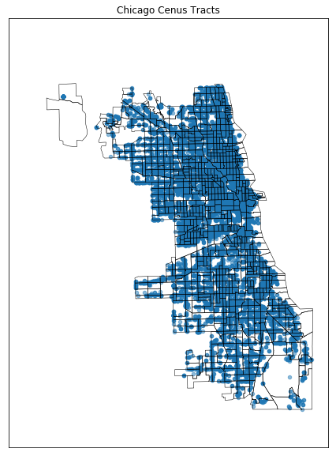

```python
fig = plt.figure(figsize=[16,10])
m = Basemap(projection='merc',llcrnrlat=41.60,urcrnrlat=42.10,\
        llcrnrlon=-88.0,urcrnrlon=-87.50,lat_ts=20,resolution='c')
m.readshapefile('./geo_export_0e3da441-8fe8-4e11-9ca0-42ef75cab68e','chicago')

failed_inspections = inspections_data.loc[inspections_data.Results == 'Fail']

lat = []
lng = []
for coordinate in failed_inspections.Location:
    lat.append(ast.literal_eval(coordinate)[0])
    lng.append(ast.literal_eval(coordinate)[1])

x,y = m(lng,lat)
plt.scatter(x,y,alpha=0.5,s=20)
plt.title("Chicago Cenus Tracts")
plt.show()
```

#### Let`s write some SQL Queries

```python
Failed_Facility_types = pd.read_sql('''SELECT Facility_Type, COUNT(Facility_Type) AS Total_Failed_Inspections FROM food_inspections WHERE Results = "Fail" GROUP BY Facility_Type ORDER BY 2 DESC LIMIT 5''', con = connection)
```

```python
Failed_Facility_types
```

|  | Facility_Type | Total_Failed_Inspections |
| --- | --- | --- |
| 0 | Restaurant | 22087 |
| 1 | Grocery Store | 5549 |
| 2 | School | 2158 |
| 3 | Bakery | 557 |
| 4 | Daycare (2 - 6 Years) | 495 |

#### Let`s see how the number of inspections varied from 2016 to 2017

```python
inspections_inc = pd.read_sql('''SELECT (SELECT count(*) FROM food_inspections WHERE year(Inspection_Date) = 2016) - (SELECT count(*) FROM food_inspections WHERE year(Inspection_Date) = 2017) AS Decrease_in_Inspections_from_2016_to_2017 ''', con = connection)
inspections_inc
```

|  | Decrease_in_Inspections_from_2016_to_2017 |
| --- | --- |
| 0 | 1234 |

```python
failed_inspections_inc = pd.read_sql('''SELECT (SELECT count(*) FROM food_inspections WHERE year(Inspection_Date) = 2016 AND Results = "Fail") - (SELECT count(*) FROM food_inspections WHERE year(Inspection_Date) = 2017 AND Results = "Fail") AS Decrease_in_failedinspections_from_2016_to_2017 ''', con = connection)
failed_inspections_inc
```

|  | Decrease_in_failedinspections_from_2016_to_2017 |
| --- | --- |
| 0 | 179 |

#### Which places have maximum number of failed inspections?

```python
failed_places = pd.read_sql('''SELECT DBA_Name, Address, Location, count(*) AS Num_of_Failed_Inspections FROM food_inspections WHERE Results = "Fail" AND License != 0 GROUP BY License ORDER BY 4 DESC LIMIT 10''', con = connection)
failed_places
```

|  | DBA_Name | Address | Location | Num_of_Failed_Inspections |
| --- | --- | --- | --- | --- |
| 0 | ILLINOIS SPORTSERVICE INC. | 333 W 35TH ST | (41.83078366228312, -87.6352957830455) | 31 |
| 1 | Orly's/Jalapeno | 1660 E 55TH ST | (41.79533443394228, -87.58427242325949) | 16 |
| 2 | JIMMY G'S | 307 S KEDZIE AVE | (41.87707753773826, -87.70586030035169) | 15 |
| 3 | JOE'S BARBQUE, INC | 4900 W MADISON ST | (41.880571145964275, -87.74795724892677) | 14 |
| 4 | IYANZE | 4623-4627 N BROADWAY | (41.96606299325794, -87.65773412452839) | 14 |
| 5 | Food 4 Less Midwest #552 | 7030 S ASHLAND AVE | (41.76579077043187, -87.66396688645497) | 13 |
| 6 | Congress Pizza | 2033 N Milwaukee AVE | (41.91826595568358, -87.68952838043421) | 13 |
| 7 | McDONALD'S | 70 E GARFIELD BLVD | (41.79479402426513, -87.62291510355041) | 13 |
| 8 | BLUE CORAL CONTEMPORARY SUSHI AND LOUNGE | 1265 N MILWAUKEE AVE | (41.90485662426528, -87.66859020422658) | 13 |
| 9 | LATIN AMERICAN REST & LOUNGE | 2743 W DIVISION ST | (41.90282132997605, -87.69614329943664) | 13 |

#### What is the percentage which didn`t pass the inspections that were carried out because of complaints?

```python
df1 = pd.read_sql('''SELECT count(*)*(100.0) / (SELECT count(*) FROM food_inspections WHERE Inspection_Type  = "Complaint") AS Percentage FROM food_inspections WHERE Inspection_Type  = "Complaint" AND Results != "Pass"''', con = connection)
df1
```

|  | Percentage |
| --- | --- |
| 0 | 55.15657 |

#### What is the percentage which didn`t pass the inspections that were carried out because of "Suspected Food Poisoning"?

```python
df2 = pd.read_sql('''SELECT count(*)*(100.0) / (SELECT count(*) FROM food_inspections WHERE Inspection_Type  = "Suspected Food Poisoning") AS Percentage FROM food_inspections WHERE Inspection_Type  = "Suspected Food Poisoning" AND Results != "Pass"''', con = connection)
df2
```

|  | Percentage |
| --- | --- |
| 0 | 51.41026 |

#### What is the percentage which didn`t pass the inspections that were carried out because of "Complaint Re-Inspection"?

```python
df3 = pd.read_sql('''SELECT count(*)*(100.0) / (SELECT count(*) FROM food_inspections WHERE Inspection_Type = "Complaint Re-Inspection") AS Percentage FROM food_inspections WHERE Inspection_Type = "Complaint Re-Inspection" AND Results != "Pass"''', con = connection)
df3
```

|  | Percentage |
| --- | --- |
| 0 | 20.28622 |

#### What is the percentage which didn`t pass the inspections that were carried out because of "Consultation"?

```python
df4 = pd.read_sql('''SELECT count(*)*(100.0) / (SELECT count(*) FROM food_inspections WHERE Inspection_Type = "Consultation") AS Percentage FROM food_inspections WHERE Inspection_Type = "Consultation" AND Results != "Pass"''', con = connection)
df4
```

|  | Percentage |
| --- | --- |
| 0 | 37.31343 |

#### Which Restaurants chains have most failed inspections?

```python
df5 = pd.read_sql('''SELECT DBA_Name, COUNT(*) as No_of_failed_inspections FROM food_inspections WHERE Results = "Fail" GROUP BY DBA_Name ORDER BY 2 DESC LIMIT 3''', con = connection)
df5
```

|  | DBA_Name | No_of_failed_inspections |
| --- | --- | --- |
| 0 | SUBWAY | 338 |
| 1 | DUNKIN DONUTS | 205 |
| 2 | MCDONALD'S | 140 |

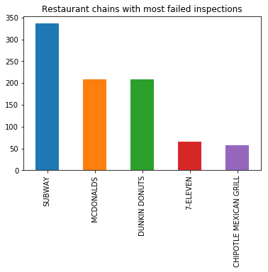

```python
inspections_data['DBA Name'][inspections_data.Results == "Fail"].value_counts()[0:5].plot(kind = 'bar', title = "Restaurant chains with most failed inspections")
```

#### Which subway restaurants failed most inspections?

```python
df6 = pd.read_sql('''SELECT License, Address, Zip, COUNT(License) AS No_of_failed_inspections FROM food_inspections WHERE DBA_Name = "SUBWAY" AND Results = "Fail" GROUP BY License ORDER BY 4 DESC LIMIT 5''', con = connection)
df6
```

|  | License | Address | Zip | No_of_failed_inspections |
| --- | --- | --- | --- | --- |
| 0 | 2262950 | 2008 N HALSTED ST | 60614 | 6 |
| 1 | 2032865 | 1212 S MICHIGAN AVE | 60605 | 6 |
| 2 | 1679112 | 8711 S ASHLAND AVE | 60620 | 6 |
| 3 | 25182 | 5040 S Cottage Grove AVE | 60615 | 6 |
| 4 | 2129629 | 2811 S KEDZIE AVE | 60623 | 6 |

#### Which individual restaurants failed most inspections?

```python
df7 = pd.read_sql('''SELECT DBA_Name, Address, Zip, COUNT(*) AS No_of_failed_inspections FROM food_inspections WHERE Facility_Type = "Restaurant" AND Results = "Fail" AND License != 0 GROUP BY License ORDER BY 4 DESC LIMIT 5''', con = connection)
df7
```

|  | DBA_Name | Address | Zip | No_of_failed_inspections |
| --- | --- | --- | --- | --- |
| 0 | Orly's/Jalapeno | 1660 E 55TH ST | 60615 | 16 |
| 1 | JIMMY G'S | 307 S KEDZIE AVE | 60612 | 15 |
| 2 | IYANZE | 4623-4627 N BROADWAY | 60640 | 14 |
| 3 | JOE'S BARBQUE, INC | 4900 W MADISON ST | 60644 | 14 |
| 4 | LATIN AMERICAN REST & LOUNGE | 2743 W DIVISION ST | 60622 | 13 |

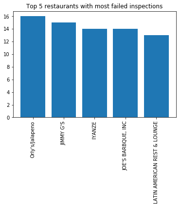

```python
plt.bar(df7['DBA_Name'], df7['No_of_failed_inspections'])
plt.xticks(rotation = "vertical")
plt.title("Top 5 restaurants with most failed inspections")
plt.show()
```

#### Addresses with most failed inspections

```python
df8 = pd.read_sql('''SELECT Address, COUNT(*) AS No_of_failed_inspections FROM food_inspections WHERE Results = "Fail" GROUP BY Address ORDER BY 2 DESC LIMIT 5''', con = connection)
df8
```

|  | Address | No_of_failed_inspections |
| --- | --- | --- |
| 0 | 11601 W TOUHY AVE | 302 |
| 1 | 324 N LEAVITT ST | 93 |
| 2 | 2300 S THROOP ST | 78 |
| 3 | 500 W MADISON ST | 73 |
| 4 | 5700 S CICERO AVE | 60 |

[figure not shown]

```python
plt.bar(df8['Address'], df7['No_of_failed_inspections'])
plt.xticks(rotation = "vertical")
plt.title("Top 5 Addresses with most failed inspections")
plt.show()
```